# Data Mining, Classification, Prediction, and Statistical Analysis

Alvaro Guevara

## Data Mining: College Students, Backpacks and Back Problems

### Introduction

The ‘Backpack’ dataset contains student survey results from a California Polytechnic State University. I chose this dataset for mining, classification, and prediction because of its focus on the physical health of college students and interesting variables which are useful for finding and uncovering different types of relationships. The data was collected to investigate whether students’ back problems might be due to carrying heavy backpacks, as well as other factors.

The variables include ‘BackpackWeight (in pounds)’, ‘BodyWeight (in pounds)’, ‘Ratio (Backpackweight/Bodyweight)’, ‘BackProblems (0=no, 1=yes)’, ‘Major’, ‘Year (in school)’, ‘Sex’, ‘Status (graduate or undergraduate)’, and ‘Units (number of credits taken)’. The dataset was readily available to use from the Stat2Data package in R. There are 100 total observations in the dataset. For the binary ‘BackProblems’ variable, there are 68 observations for the ‘0’ group (no back problems), and 32 for the ‘1’ group (back problems).

```r
library(tidyverse)
library(dplyr)

# Read dataset
library(Stat2Data)
data(Backpack)
Backpack <- Backpack

# Observations per group
Backpack %>% group_by(BackProblems) %>% summarize(n = n())
```

```
## # A tibble: 2 x 2
##   BackProblems     n
##          <int> <int>
## 1            0    68
## 2            1    32
```

### Cluster Analysis

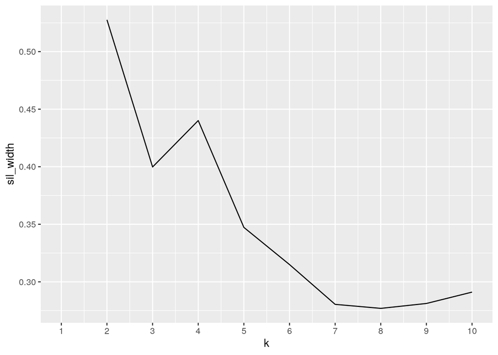

```r
library(cluster)
library(GGally)

# Choose the number of clusters that maximizes average
# silhouette width
pam_dat <- Backpack %>% select(1, 2, 6, 9)
sil_width <- vector()
for (i in 2:10) {
    pam_fit <- pam(pam_dat, k = i)
    sil_width[i] <- pam_fit$silinfo$avg.width
}
ggplot() + geom_line(aes(x = 1:10, y = sil_width)) + scale_x_continuous(name = "k",
    breaks = 1:10)
```

```r
# Running PAM
set.seed(322)  #just makes our output match
backpack_pam <- pam_dat %>% pam(k = 2)  #use the pam function
backpack_pam
```

```
## Medoids:
##      ID BackpackWeight BodyWeight Year Units
## [1,] 57             10        130    2    15
## [2,] 16             11        175    4    16
## Clustering vector:
##   [1] 1 2 1 2 2 2 2 2 1 1 1 2 2 2 1 2 1 1 1 2 2 1 1 2 2 2 1 1 2 2 1 1 1 1 2 1 1
##  [38] 2 2 1 1 1 1 2 1 1 1 1 2 1 2 2 1 2 1 1 1 2 1 1 2 1 2 1 2 2 1 1 1 1 2 2 1 1
##  [75] 2 1 1 1 1 1 2 1 1 1 1 1 1 1 2 2 1 2 2 2 2 2 2 1 1 2
## Objective function:
##    build     swap
## 17.80726 14.89034
##
## Available components:
##  [1] "medoids"    "id.med"     "clustering" "objective"  "isolation"
##  [6] "clusinfo"   "silinfo"    "diss"       "call"       "data"
```

```r
# Interpreting Average Silhouette Width
backpack_pam$silinfo$avg.width
```

```
## [1] 0.5276162
```

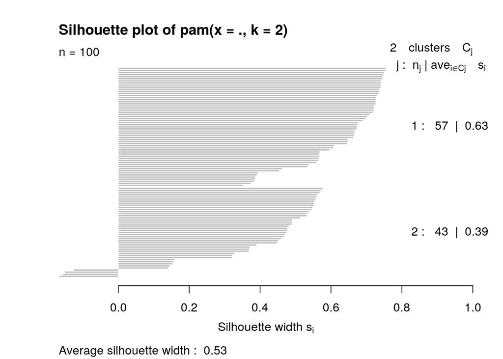

```r
plot(backpack_pam, which = 2)
```

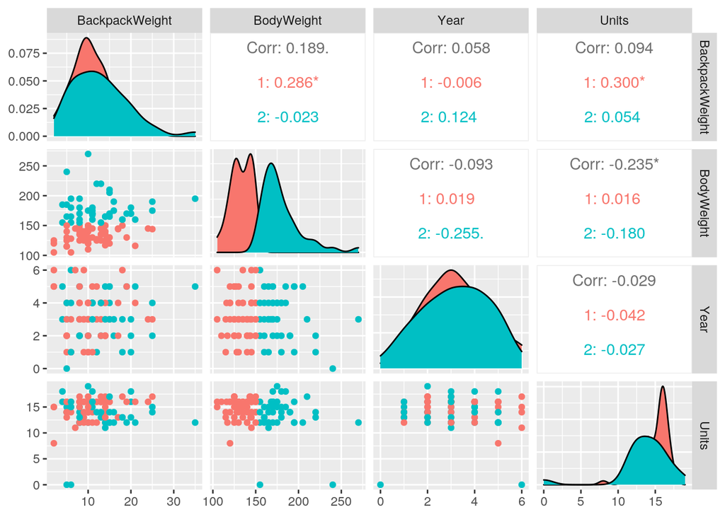

```r
# Plot every pairwise scatterplot using ggpairs
Backpack %>% select(1, 2, 6, 9) %>% mutate(cluster = as.factor(backpack_pam$clustering)) %>%
    ggpairs(columns = c("BackpackWeight", "BodyWeight", "Year",
        "Units"), aes(color = cluster))
```

The number of clusters that are best to use and which maximize the average silhoutte width were determined to be 2. After running PAM, I found that the two medoids are student IDs 57 and 16. The two medoids are most similar on backpack weight and units. They are close in year. They are most different on body weight. After interpreting average silhoutte width, the cluster solution is found to be a reasonable structure since the average silhouette width of 0.53 falls between 0.51 and 0.70.

Looking at the pairwise scatterplots, the ‘BodyWeight’ variable seems to show the greatest difference between the two clusters. The ‘Backpack’ variable seems to show the least difference between the two clusters. Looking at the density plots, cluster 1 (red), it is lower in body weight and higher in units. When looking at cluster 2 (blue), it is higher in body weight and lower in units. The density plots for the two clusters are about the same for backpack weight and year.

### Dimensionality Reduction with PCA

```r
# PCA
backpack_nums <- Backpack %>% select(1, 2, 6, 9) %>% scale
backpack_pca <- princomp(backpack_nums, cor = T)

# Get PCA summary
summary(backpack_pca, loadings = T)
```

```
## Importance of components:
##                          Comp.1    Comp.2    Comp.3    Comp.4
## Standard deviation     1.124756 1.0473188 1.0099067 0.7862161
## Proportion of Variance 0.316269 0.2742192 0.2549779 0.1545339
## Cumulative Proportion  0.316269 0.5904882 0.8454661 1.0000000
##
## Loadings:
##                Comp.1 Comp.2 Comp.3 Comp.4
## BackpackWeight  0.319  0.812         0.488
## BodyWeight      0.762               -0.636
## Year           -0.137  0.248 -0.920 -0.270
## Units          -0.547  0.523  0.378 -0.533
```

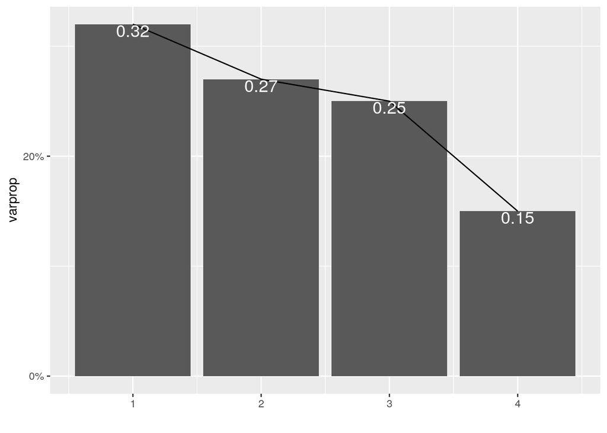

```r
# Scree plot
eigval <- backpack_pca$sdev^2  #square to convert SDs to eigenvalues
varprop = round(eigval/sum(eigval), 2)  #proportion of var explained by each PC

ggplot() + geom_bar(aes(y = varprop, x = 1:4), stat = "identity") +
    xlab("") + geom_path(aes(y = varprop, x = 1:4)) + geom_text(aes(x = 1:4,
    y = varprop, label = round(varprop, 2)), vjust = 1, col = "white",
    size = 5) + scale_y_continuous(breaks = seq(0, 0.6, 0.2),
    labels = scales::percent) + scale_x_continuous(breaks = 1:10)
```

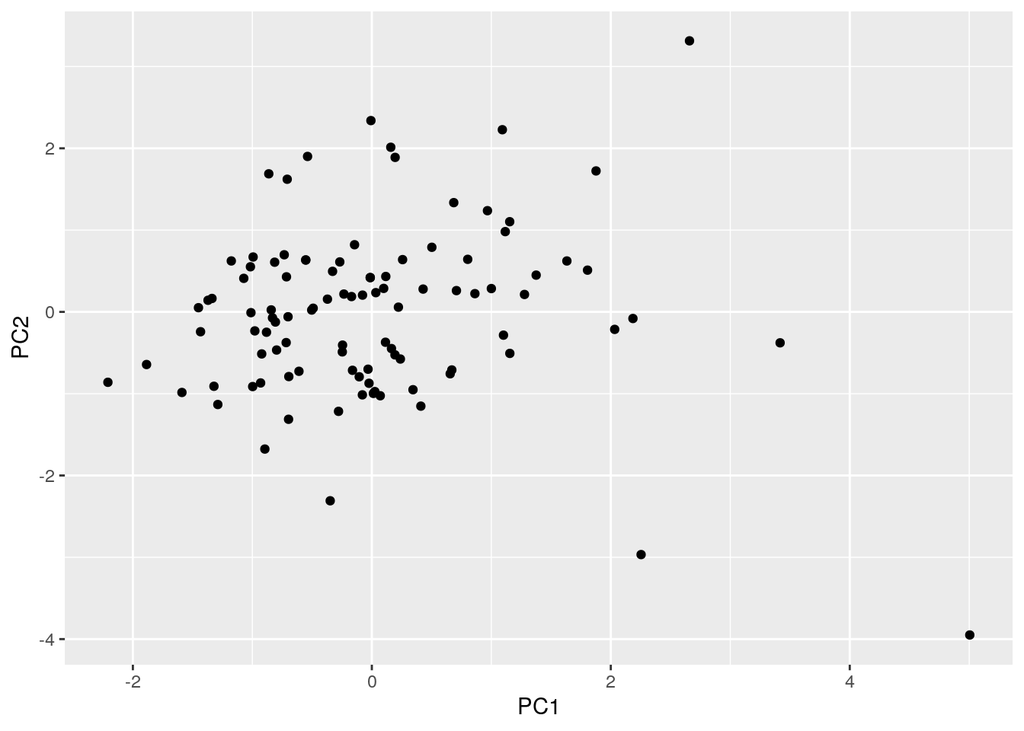

```r
# Save the first two PCs in a dataframe
backpackdf <- data.frame(PC1 = backpack_pca$scores[, 1], PC2 = backpack_pca$scores[,
    2])

# Plot them
ggplot(backpackdf, aes(PC1, PC2)) + geom_point()
```

For Principal Component 1, it captures around 32% of the total variance in the ‘Backpack’ dataset/original variables. For PC 2, with the added ‘proportion of variance’ of 0.274, it captures around 59% of the total variance in the original variables. For PC 3, with a proportion of .254, it captures around 85% of the total variance in the original variables. We can retain 3 PCs since the cumulative proportion variance is at 85%, which means it is enough so that it can summarize the total variability of the dataset.

### Linear Classifier

```r
# Predict back problems from all 5 numeric variables using
# logistic regression
logistic_fit <- glm(BackProblems == 1 ~ BackpackWeight + BodyWeight +
    Ratio + Year + Units, data = Backpack, family = "binomial")

# Generate predicted score/probabilities
prob_reg <- predict(logistic_fit, type = "response")
# Compute classification diagnostics
class_diag(prob_reg, Backpack$BackProblems == 1, positive = 1)
```

```
##          acc  sens   spec ppv  f1     ba    auc
## Metrics 0.68 0.125 0.9412 0.5 0.2 0.5331 0.6622
```

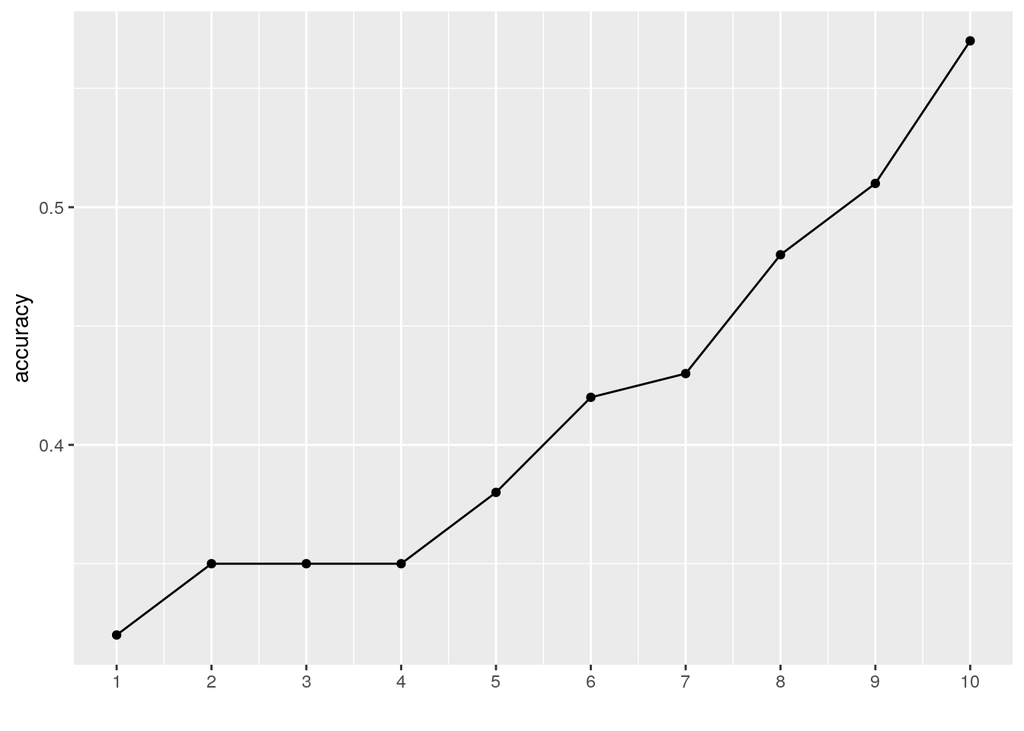

```r
# Classification based on backpack weight
y <- Backpack$BackProblems
x <- Backpack$BackpackWeight
y <- factor(y, levels = c(1, 0))

accuracy <- vector()
cutoff <- 1:10
for (i in cutoff) {
    y_hat <- ifelse(x > i, 1, 0)
    accuracy[i] <- mean(y == y_hat)
}
qplot(y = accuracy) + geom_line() + scale_x_continuous(breaks = 1:10)
```

```r
# Accuracy of 57%
y_hat <- ifelse(x > 10, 1, 0)
mean(y == y_hat)
```

```
## [1] 0.57
```

```r
# Confusion matrix for back problems predictions based on
# backpack weight
y_hat <- factor(y_hat, levels = c(1, 0))
table(actual = y, predicted = y_hat) %>% addmargins
```

```
##       predicted
## actual   1   0 Sum
##    1    20  12  32
##    0    31  37  68
##    Sum  51  49 100
```

```r
library(tidyverse)
library(dplyr)

# Cross-validation of linear classifier
set.seed(322)
k = 5

data <- sample_frac(Backpack)  #randomly order rows
folds <- rep(1:k, length.out = nrow(data))  #create folds

diags <- NULL

i = 1
for (i in 1:k) {
    # Create training and test sets
    train <- data[folds != i, ]
    test <- data[folds == i, ]
    truth <- test$BackProblems

    # Train model
    fit <- glm(BackProblems == 1 ~ BackpackWeight + BodyWeight +
        Ratio + Year + Units, data = train, family = "binomial")  ### SPECIFY THE LOGISTIC REGRESSION MODEL FIT TO THE TRAINING SET HERE

    # Test model
    probs <- predict(fit, newdata = test, type = "response")  ### GET PREDICTIONS FROM THE TRAINED MODEL ON THE TEST SET HERE

    # Get performance metrics for each fold
    diags <- rbind(diags, class_diag(probs, truth, positive = 1))
}

# Average performance metrics across all folds
summarize_all(diags, mean)
```

```
##    acc sens    spec ppv  f1      ba    auc
## 1 0.64 0.08 0.92166 NaN NaN 0.50084 0.5758
```

There are no signs of overfitting since the logistic regression model is performing poorly on new predictions given that the area under the curve is 0.66, which is between the cutoffs of 0.6 and 0.7.

For classification, I decided to classify the outcome (no back problems vs. back problems), based on backpack weight. I computed the accuracy by obtaining different cutoffs which I then visualized with the qplot() fuction from ggplot2. I found the optimized cutoff to be 10. I then used this cutoff to find that the best accuracy for students correctly classified as having back problems based on backpack weight was around 57%.

Looking at the confusion matrix, the Sensitivity/TPR (true positive rate)- proportion of actual positives correctly classified- was 0.625, which meant the FNR (false negative rate) was 0.375. The Specificity/TNR (true negative rate)- proportion of actual negatives correctly classified- was 0.54, which meant the FPR (false positive rate) was 0.46. The precision/PPV (positive predictive value)- proportion of cases predicted positive that are actually positive- was 0.39.

When doing cross-validation on the logistic regression model, there is a real decrease in AUC when predicting out of sample. The AUC went down to 0.58, which means it’s performing bad on new predictions.

### Non-Parametric Classifier

```r
library(caret)
# Non-parametric classifier
knn_fit <- knn3(BackProblems == 1 ~ BackpackWeight + BodyWeight +
    Ratio + Year + Units, data = Backpack)

# Generate predicted scores/probabilities
prob_knn <- predict(knn_fit, Backpack)

# Compute classification diagnostics
class_diag(prob_knn[, 2], Backpack$BackProblems == 1, positive = 1)
```

```
##          acc   sens   spec    ppv     f1     ba    auc
## Metrics 0.78 0.5312 0.8971 0.7083 0.6071 0.7142 0.8362
```

```r
# Confusion matrix
table(truth = factor(Backpack$BackProblems == 1, levels = c("TRUE",
    "FALSE")), prediction = factor(prob_knn[, 2] > 0.5, levels = c("TRUE",
    "FALSE"))) %>% addmargins
```

```
##        prediction
## truth   TRUE FALSE Sum
##   TRUE    17    15  32
##   FALSE    7    61  68
##   Sum     24    76 100
```

```r
# Cross-validation of np classifier
set.seed(322)
k = 5

data <- sample_frac(Backpack)  #randomly order rows
folds <- rep(1:k, length.out = nrow(data))  #create folds

diags <- NULL

i = 1
for (i in 1:k) {
    # Create training and test sets
    train <- data[folds != i, ]
    test <- data[folds == i, ]
    truth <- test$BackProblems

    # Train model
    fit <- knn3(BackProblems == 1 ~ BackpackWeight + BodyWeight +
        Ratio + Year + Units, data = train)  ### SPECIFY THE KNN MODEL FIT TO THE TRAINING SET HERE

    # Test model
    probs <- predict(fit, newdata = test)[, 2]  ### GET PREDICTIONS FROM THE TRAINED MODEL ON THE TEST SET HERE

    # Get performance metrics for each fold
    diags <- rbind(diags, class_diag(probs, truth, positive = 1))
}

# Average performance metrics across all folds
summarize_all(diags, mean)
```

```
##    acc    sens    spec     ppv  f1      ba     auc
## 1 0.66 0.35332 0.82516 0.49166 NaN 0.58924 0.64188
```

There are no signs of overfitting since the AUC in the kNN model isn’t at 1 or near it. However, the kNN model is performing good on new predictions given that the area under the curve is 0.84, which is between the cutoffs of 0.8 and 0.9.

Looking at the confusion matrix, the Sensitivity/TPR was 0.53, which meant the FNR was 0.47. The Specificity/TNR was 0.9, which meant the FPR was 0.1. The precision/PPV was 0.71.

When doing cross-validation on the kNN model, there is a significant decrease in the AUC when predicting out of sample. The AUC went down to 0.64, which means it’s performing poor on new predictions. The kNN non-parametric model performed the best on new data since even though there was a significant decrease when cross validating, the AUC was still higher compared to the logistic regression model.

### Regression/Numeric Prediction

```r
# Linear regression model
fit1 <- lm(BackpackWeight ~ BodyWeight + Units + Year, data = Backpack)  #predict backpack weight from body weight, units, and year
yhat <- predict(fit1)  #predicted backpack weight

mean((Backpack$BackpackWeight - yhat)^2)  #mean squared error (MSE)
```

```
## [1] 30.82455
```

```r
# Cross-validation of regression model here
set.seed(1234)
k = 5  #choose number of folds
data <- Backpack[sample(nrow(Backpack)), ]  #randomly order rows
folds <- cut(seq(1:nrow(Backpack)), breaks = k, labels = F)  #create folds
diags <- NULL
for (i in 1:k) {
    train <- data[folds != i, ]
    test <- data[folds == i, ]
    ## Fit linear regression model to training set
    fit2 <- lm(BackpackWeight ~ BodyWeight + Units + Year, data = train)
    ## Get predictions/y-hats on test set (fold i)
    yhat <- predict(fit2, newdata = test)
    ## Compute prediction error (MSE) for fold i
    diags <- mean((test$BackpackWeight - yhat)^2)
}
mean(diags)  ## get average MSE across all folds (much higher error)!
```

```
## [1] 27.80354
```

For the linear regression model, the mean squared error was 30.8. With cross-validation of the linear regression model, the mean squared error slightly decreased to 27.8. The model does not seem to show any signs of overfitting since the MSE was lower, not higher, after CV.

### Python

```r
## R chunk

library(reticulate)
use_python("/usr/bin/python3", required = F)
matplotlib <- import("matplotlib")
matplotlib$use("Agg", force = TRUE)


# Mean backpack weight
averagebpw <- mean(Backpack$BackpackWeight)

# Standard deviation of backpack weight
stdevbw <- sd(Backpack$BodyWeight)

# Variance of backpack weight
varbw <- var(Backpack$BodyWeight)

# Did the student with the highest backpack weight have back
# problems?
maxbpw <- Backpack %>% filter(BackpackWeight == max(BackpackWeight))
maxbpw
```

```
##   BackpackWeight BodyWeight    Ratio BackProblems Major Year  Sex Status Units
## 1             35        195 0.179487            0  Aero    5 Male      U    12
```

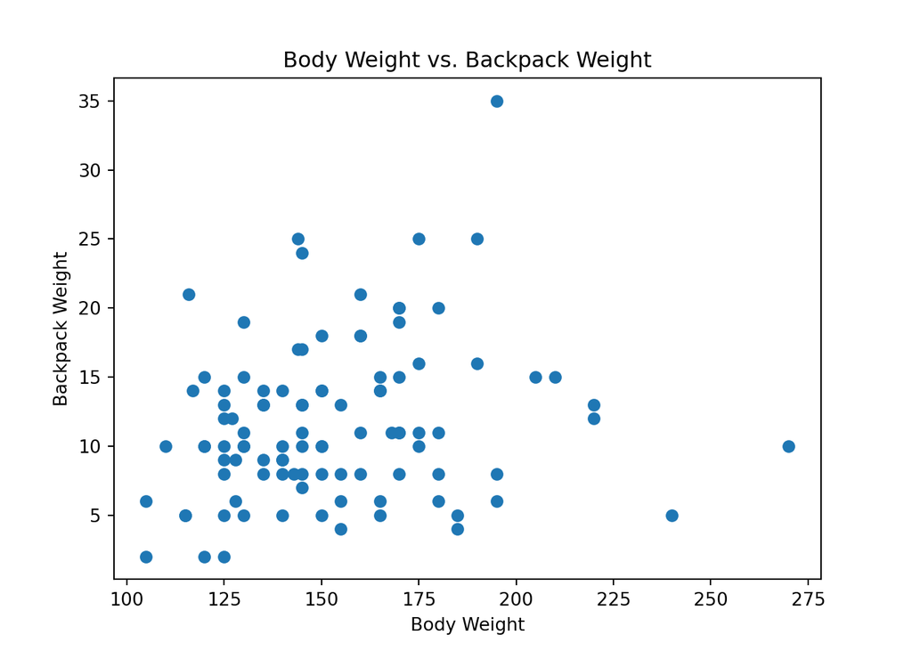

```python
## Python chunk

import matplotlib.pyplot as plt

# Read R dataset to Python
backpack1 = r.Backpack

# Standard deviation of backpack weight
stdevbpw = backpack1["BackpackWeight"].std()

# Variance of backpack weight
varbpw = backpack1["BackpackWeight"].var()

# Length of dataset
length_data = len(backpack1)

# Mean body weight
avrgbw = backpack1["BodyWeight"].mean()


# Scatterplot for body weight and backpack weight
x = backpack1.BodyWeight
y = backpack1.BackpackWeight

plt.scatter(x, y)
plt.xlabel("Body Weight")
plt.ylabel("Backpack Weight")
plt.title("Body Weight vs. Backpack Weight")
plt.show()

# Correlation between body weight and backpack weight
```

```python
correlation = backpack1.BodyWeight.corr(backpack1.BackpackWeight)
print(correlation)
```

```
## 0.18933115120474284
```

```r
## R chunk
library(reticulate)
use_python("/usr/bin/python3", required = F)
matplotlib <- import("matplotlib")
matplotlib$use("Agg", force = TRUE)

# communicate with Python code by showing output
cat(c(averagebpw, py$stdevbpw, py$varbpw, py$length_data, py$avrgbw,
    stdevbw, varbw))
```

```
## 11.66 5.765134 33.23677 100 153.05 29.39744 864.2096
```

```python
## Python chunk

# Communicate with R code by showing output
print(r.averagebpw, stdevbpw, varbpw, length_data, avrgbw, r.stdevbw, r.varbw)
```

```
## 11.66 5.765133795218259 33.236767676767684 100 153.05 29.39744199687442 864.209595959596
```

```python
print(r.maxbpw)
```

```
##    BackpackWeight  BodyWeight     Ratio  ...     Sex Status  Units
## 0              35         195  0.179487  ...    Male      U     12
##
## [1 rows x 9 columns]
```

I decided to analyze the ‘Backpack’ dataset even further by running summary statistics on the variables ‘BodyWeight’ and ‘BackpackWeight’. I used the R reticulate package to run Python code in R. Some of the summary statistics were done in R code and some in Python, but I communicated between them in the same R interface for smooth integration. I found that the average backpack weight was 11.66 pounds and the average body weight to be 153.05. After seeing these summary statistics, I wanted to see if the student with the highest backpack weight had back problems. Looking at the results, the student with the highest backpack weight did not have any back problems which proved my assumptions wrong.

Running the Matplotlob library in Python, I decided to discover the relationship between body weight and backpack weight by visualizing it in a scatterplot. The scatterplot showed that there actually was some kind of relationship between the variables. Investigating even further I found the correlation between the two variables to be 0.189, which is a positive but extremely weak correlation.

### Concluding Remarks

There were many results from the data mining project that helped me understand the importance of training and testing data for new predictions. The data someone is working with can either be really great at predicting new data, or as I found, very poor. I also understood how to see relationships between groups when clustering data. The importance being that hidden patterns and relationships can be discovered in a dataset that one wouldn’t have been able to see otherwise. Findings from data mining, classification, and prediction processes can lead to significant changes that improve upon goals, strategies and research in professional or academic settings.